# Machine Learning - Assignment 1

**Margarida Passos da Cunha | 71119**  
**Course:** 2767 Machine Learning

## Notebook Structure

| Section | Content |
| --- | --- |
| 0 | Setup & Imports |
| 1 | Data Loading & Initial Inspection |
| 2 | **Q1** – Exploratory Data Analysis |
| 3 | **Q2** – Predictive Modelling |
| 4 | **Q3** – Model Evaluation |
| 5 | **Q4** – Deployment & Reproducibility |
| 6 | **Q5** – Strategic Insights |

## Section 0 – Setup & Imports

```python
# ── Core ────────────────────────────────────────────────────────────────────
import pandas as pd
import numpy as np
import warnings
warnings.filterwarnings('ignore')

# ── Visualisation ────────────────────────────────────────────────────────────
import matplotlib.pyplot as plt
import matplotlib.ticker as mticker
import seaborn as sns

sns.set_theme(style='whitegrid', palette='muted', font_scale=1.1)
plt.rcParams['figure.dpi'] = 120

# ── Statistics ───────────────────────────────────────────────────────────────
from scipy.stats import chi2_contingency
from scipy.stats.contingency import association

# ── Sklearn ──────────────────────────────────────────────────────────────────
from sklearn.model_selection import train_test_split, StratifiedKFold, RandomizedSearchCV
from sklearn.pipeline import Pipeline
from sklearn.compose import ColumnTransformer
from sklearn.preprocessing import StandardScaler, OneHotEncoder, FunctionTransformer
from sklearn.impute import SimpleImputer
from sklearn.linear_model import LogisticRegression
from sklearn.ensemble import RandomForestClassifier, GradientBoostingClassifier
from sklearn.metrics import (
    classification_report, confusion_matrix,
    f1_score, roc_auc_score, precision_score,
    recall_score, average_precision_score,
    ConfusionMatrixDisplay, RocCurveDisplay
)

# ── Serialisation ─────────────────────────────────────────────────────────────
import pickle

# ── Reproducibility seed ──────────────────────────────────────────────────────
SEED = 42
np.random.seed(SEED)

print('All libraries loaded successfully.')
```

```
All libraries loaded successfully.
```

## Section 1 – Data Loading & Initial Inspection

```python
# ── Load training data ────────────────────────────────────────────────────────
# Adjust path if needed – unzip complaints_training.csv.zip first
df_raw = pd.read_csv('complaints_training.csv', low_memory=False)

print(f'Dataset shape: {df_raw.shape}')
print(f'Columns: {df_raw.columns.tolist()}')
```

[output not shown]

```python
# ── Basic overview ────────────────────────────────────────────────────────────
df_raw.info()
```

```
<class 'pandas.core.frame.DataFrame'>
RangeIndex: 321430 entries, 0 to 321429
Data columns (total 18 columns):
 #   Column                        Non-Null Count   Dtype
---  ------                        --------------   -----
 0   Date received                 321430 non-null  object
 1   Product                       321430 non-null  object
 2   Sub-product                   223355 non-null  object
 3   Issue                         321430 non-null  object
 4   Sub-issue                     151075 non-null  object
 5   Consumer complaint narrative  54739 non-null   object
 6   Company public response       61833 non-null   object
 7   Company                       321430 non-null  object
 8   State                         319285 non-null  object
 9   ZIP code                      320067 non-null  object
 10  Tags                          48699 non-null   object
 11  Consumer consent provided?    99633 non-null   object
 12  Submitted via                 321430 non-null  object
 13  Date sent to company          321430 non-null  object
 14  Company response to consumer  321430 non-null  object
 15  Timely response?              321430 non-null  object
 16  Consumer disputed?            321430 non-null  object
 17  Complaint ID                  321430 non-null  int64
dtypes: int64(1), object(17)
memory usage: 44.1+ MB
```

```python
# ── Missing value summary ─────────────────────────────────────────────────────
missing = df_raw.isnull().sum()
missing_pct = (missing / len(df_raw) * 100).round(2)
pd.DataFrame({'Missing Count': missing, 'Missing %': missing_pct}).sort_values('Missing %', ascending=False)
```

|  | Missing Count | Missing % |
| --- | --- | --- |
| Tags | 272731 | 84.85 |
| Consumer complaint narrative | 266691 | 82.97 |
| Company public response | 259597 | 80.76 |
| Consumer consent provided? | 221797 | 69.00 |
| Sub-issue | 170355 | 53.00 |
| Sub-product | 98075 | 30.51 |
| State | 2145 | 0.67 |
| ZIP code | 1363 | 0.42 |
| Date sent to company | 0 | 0.00 |
| Consumer disputed? | 0 | 0.00 |
| Timely response? | 0 | 0.00 |
| Company response to consumer | 0 | 0.00 |
| Date received | 0 | 0.00 |
| Submitted via | 0 | 0.00 |
| Product | 0 | 0.00 |
| Company | 0 | 0.00 |
| Issue | 0 | 0.00 |
| Complaint ID | 0 | 0.00 |

```python
# ── Target variable: Consumer disputed? ──────────────────────────────────────
print('Raw target value counts:')
print(df_raw['Consumer disputed?'].value_counts(dropna=False))
print()

# Remove N/A – post-April 2017 the dispute option was discontinued
# Keeping N/A would contaminate the binary classification target
df = df_raw[df_raw['Consumer disputed?'].isin(['Yes', 'No'])].copy()

# Encode target: 1 = Disputed (Yes), 0 = Not Disputed (No)
df['target'] = (df['Consumer disputed?'] == 'Yes').astype(int)

print(f'\nRecords after removing N/A: {len(df):,}')
print('\nTarget distribution:')
vc = df['target'].value_counts()
for val, cnt in vc.items():
    label = 'Disputed' if val == 1 else 'Not Disputed'
    print(f'  {val} ({label}): {cnt:,}  ({cnt/len(df)*100:.1f}%)')
```

```
Raw target value counts:
Consumer disputed?
No     257436
Yes     63994
Name: count, dtype: int64


Records after removing N/A: 321,430

Target distribution:
  0 (Not Disputed): 257,436  (80.1%)
  1 (Disputed): 63,994  (19.9%)
```

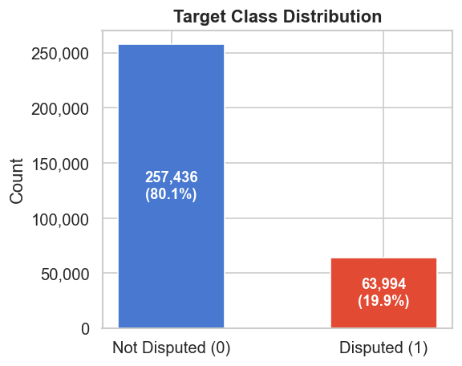

```python
# ── Visual: Class imbalance ───────────────────────────────────────────────────
fig, ax = plt.subplots(figsize=(5, 4))
vc_plot = df['target'].value_counts()
ax.bar(['Not Disputed (0)', 'Disputed (1)'], vc_plot.values,
       color=['#4878CF', '#E24A33'], edgecolor='white', width=0.5)
for bar, val in zip(bars, vc_plot.values):
    ax.text(
        bar.get_x() + bar.get_width() / 2,
        bar.get_height() * 0.5,
        f'{val:,}\n({val / len(df) * 100:.1f}%)',
        ha='center', va='center',
        fontsize=11, fontweight='bold', color='white'
    )
ax.set_title('Target Class Distribution', fontweight='bold')
ax.set_ylabel('Count')
ax.yaxis.set_major_formatter(mticker.FuncFormatter(lambda x, _: f'{int(x):,}'))
plt.tight_layout()
plt.savefig('fig_class_distribution.png', bbox_inches='tight')
plt.show()
```

The dataset contains **321,430 complaints** after removing records with no dispute outcome (N/A). The class distribution is moderately imbalanced: **80.1% Not Disputed** vs **19.9% Disputed**. This imbalance is important — it means a naive model that always predicts "Not Disputed" would achieve 80% accuracy while being entirely useless. We will need to account for this in modelling (Q2).

# Question 1

## Q1.1

The executive team at Meridian Financial Group holds three informal assumptions about complaint escalation:

1. **Product assumption** – certain products generate disproportionately more disputes.
2. **Digital channel assumption** – complaints submitted online escalate more frequently.
3. **Regional assumption** – escalation rates vary significantly across US states.

The approach for each assumption follows the same structure:

1. **Explore visually** — what does the data suggest at first glance?
2. **Test statistically** — is the observed pattern real or due to chance?
3. **Conclude** — what does this mean for the business?

We use **chi-squared tests** for statistical significance (appropriate for two categorical variables and large samples) and **Cramér's V** to measure effect size (how strong the association is, not just whether it exists).

```python
# ── Helper: compute escalation stats per group ────────────────────────────────
def escalation_stats(df, col):
    return (
        df.groupby(col)['target']
        .agg(total='count', disputed='sum')
        .assign(escalation_rate=lambda x: (x['disputed'] / x['total'] * 100).round(2))
        .sort_values('escalation_rate', ascending=False)
    )

# ── Helper: run chi-squared + Cramér's V ─────────────────────────────────────
def run_chi2(df, col):
    ct = pd.crosstab(df[col], df['target'])
    chi2, p, dof, _ = chi2_contingency(ct)
    v = association(ct, method='cramer')
    sig = 'YES — statistically significant (p < 0.05)' if p < 0.05 else 'NO — not statistically significant'
    strength = 'negligible' if v < 0.1 else ('weak' if v < 0.2 else ('moderate' if v < 0.3 else 'strong'))
    print(f'  Chi-squared: χ²={chi2:.1f}, df={dof}, p={p:.2e}')
    print(f'  Cramér\'s V: {v:.3f} → {strength} association')
    print(f'  Significant: {sig}')
    return chi2, p, dof, v

baseline_rate = df['target'].mean() * 100
print(f'Overall escalation baseline: {baseline_rate:.2f}%')
```

```
Overall escalation baseline: 19.91%
```

### Assumption 1 – Do certain products drive escalation?

```python
# ── Escalation rate by Product ────────────────────────────────────────────────
product_stats = escalation_stats(df, 'Product')
print(product_stats.to_string())
```

```
                         total  disputed  escalation_rate
Product
Virtual currency             8         5            62.50
Mortgage                 85296     20170            23.65
Consumer Loan            13336      3017            22.62
Credit card              31274      6664            21.31
Bank account or service  31802      6266            19.70
Student loan              8783      1708            19.45
Other financial service    428        80            18.69
Debt collection          78794     14543            18.46
Credit reporting         63510     10355            16.30
Payday loan               3291       522            15.86
Money transfers           2788       387            13.88
Prepaid card              2120       277            13.07
```

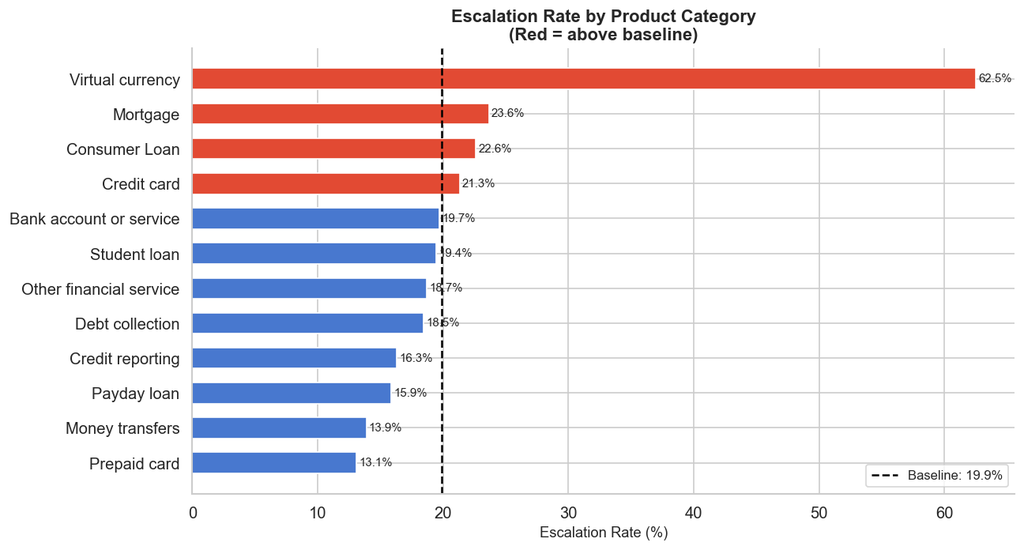

```python
# ── Visual 1a: Escalation rate by product (bar chart) ────────────────────────
fig, ax = plt.subplots(figsize=(11, 6))

ps = product_stats.sort_values('escalation_rate')
colors = ['#E24A33' if r > baseline_rate else '#4878CF' for r in ps['escalation_rate']]
bars = ax.barh(ps.index, ps['escalation_rate'], color=colors, edgecolor='white', height=0.6)

ax.axvline(baseline_rate, color='black', linestyle='--', linewidth=1.5,
           label=f'Baseline: {baseline_rate:.1f}%')
for bar, val in zip(bars, ps['escalation_rate']):
    ax.text(val + 0.2, bar.get_y() + bar.get_height()/2,
            f'{val:.1f}%', va='center', fontsize=9)

ax.set_xlabel('Escalation Rate (%)', fontsize=11)
ax.set_title('Escalation Rate by Product Category\n(Red = above baseline)', fontweight='bold')
ax.legend(fontsize=10)
sns.despine()
plt.tight_layout()
plt.savefig('fig_product_escalation_bar.png', bbox_inches='tight')
plt.show()
```

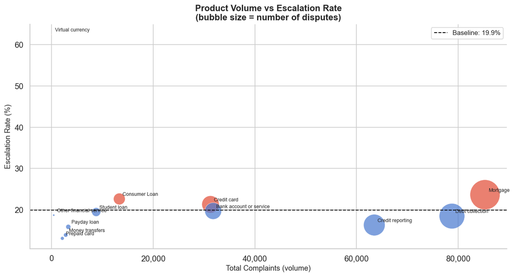

```python
# ── Visual 1b: Volume vs escalation rate (bubble chart) ──────────────────────
fig, ax = plt.subplots(figsize=(11, 6))

scatter = ax.scatter(
    product_stats['total'],
    product_stats['escalation_rate'],
    s=product_stats['disputed'] / 10,
    c=['#E24A33' if r > baseline_rate else '#4878CF' for r in product_stats['escalation_rate']],
    alpha=0.7, edgecolors='white', linewidth=0.5
)

for _, row in product_stats.iterrows():
    label = row.name if len(row.name) < 30 else row.name[:27] + '...'
    ax.annotate(label, (row['total'], row['escalation_rate']),
                fontsize=7.5, ha='left', va='bottom',
                xytext=(5, 3), textcoords='offset points')

ax.axhline(baseline_rate, color='black', linestyle='--', linewidth=1.2,
           label=f'Baseline: {baseline_rate:.1f}%')
ax.set_xlabel('Total Complaints (volume)', fontsize=11)
ax.set_ylabel('Escalation Rate (%)', fontsize=11)
ax.set_title('Product Volume vs Escalation Rate\n(bubble size = number of disputes)',
             fontweight='bold')
ax.legend(fontsize=10)
ax.xaxis.set_major_formatter(mticker.FuncFormatter(lambda x, _: f'{int(x):,}'))
sns.despine()
plt.tight_layout()
plt.savefig('fig_product_bubble.png', bbox_inches='tight')
plt.show()
```

The charts reveal a clear pattern: escalation rates vary substantially across products, and some categories sit well above the 19.9% baseline. The bubble chart adds an important nuance — **high volume does not automatically mean high escalation rate**. A product can generate many complaints without those complaints escalating at an unusual rate, and vice versa.

Now let's test whether these differences are statistically significant or could simply be due to random variation.

```python
# ── Statistical test: Product vs Disputed ────────────────────────────────────
print('Statistical Test: Product → Escalation')
print('─' * 50)
chi2_p, p_p, dof_p, v_p = run_chi2(df, 'Product')
```

```
Statistical Test: Product → Escalation
──────────────────────────────────────────────────
  Chi-squared: χ²=1640.3, df=11, p=0.00e+00
  Cramér's V: 0.071 → negligible association
  Significant: YES — statistically significant (p < 0.05)
```